# Tidy Time Series Forecasting with Fable

Michael Rose

## Resources

### Packages

- tsibble (dplyr)
- tsibbledata
- fable (models)
- hts (hierarchical time series)
- tbats (trigonometric seasonality, boxcox transformation, arma errors, trend and seasonal components)
- prophet
- mists (missing values)
- feasts (feature engineering)
- fasster
- sweep (broom)
- sugrrants (ggplot2)

### Books

- Forecasting: Principles and Practice
- Tidy Forecasting Principles
- Hamilton Time Series Analysis

## tsibble

## Forecasting

### 1 | Fable

The fable package is a tidy renovation of the forecast package. Much like tsibble implements tidy time series data, the fable package applies tidyverse principles to time series modeling.

### 2 | Tidy Time Series

The tsibble package provides a tidy data structure for time series. It is sufficiently flexible to support the future of time series modeling tools (such as tbats, fasster, and prophet). The tsibble object also provides valuable structural information (index and key).

**index**

This can be used to identify the frequency and regularity of the observations. By storing a standard datetime object within the dataset, it makes irregular time series modeling possible. It also allows a more flexible specification of seasonal frequency that is easier to specify for the end user.

**key**

Keys are used within tsibble to uniquely identify related time series in a tidy structure. They are also useful for identifying relational structures between each time series.

This is especially useful for forecast reconciliation, where a hierarchical or grouped structure is imposed on a set of forecasts to impost relational constraints (typically aggregation).

Keys within tsibble can either be nested (hierarchical) or crossed (grouped), and can be directly used to reconcile forecasts. This structure also has purpose for univariate models, as it allows batch forecasting to be applied across many time series.

### 3 | Model Basics

The model function expects to accept a tsibble and a model formula and return a fitted model stored as a mable.

The model function may look like this:

```r
log(y) ~ trend() + season(period = "day") + x
```

### 4 | Accessing Model Elements

The print and summary methods are standard displays for fitted models. The print method typically displays a limited amount of key information, such as the model that was fit and the coefficients.

As fable naturally supports batch / multiple forecasting, the print method is standardized for any number of models.

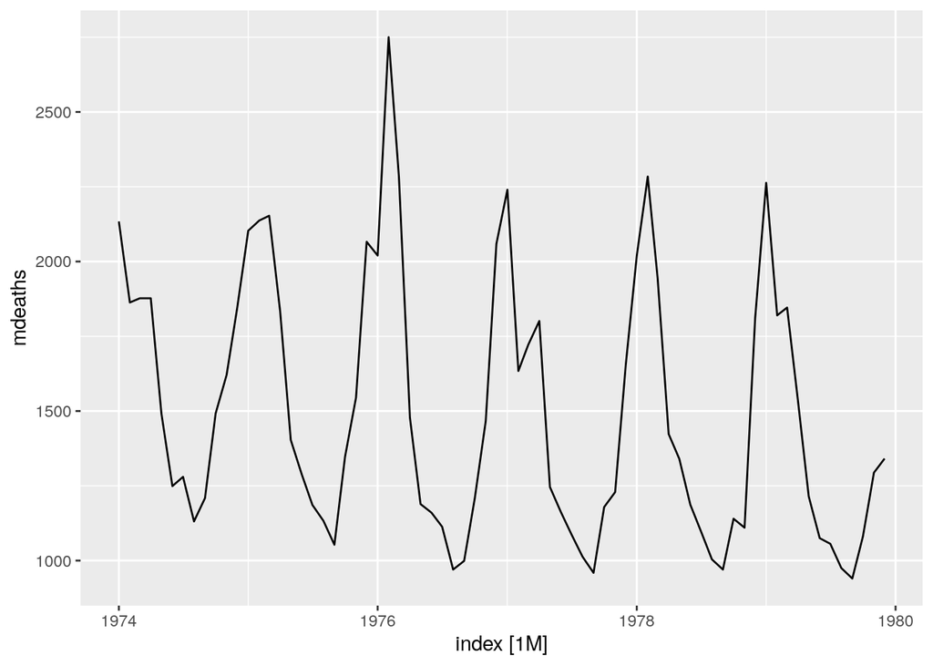

```r
# load data from tsibbledata
uk_lung <- as_tsibble(cbind(mdeaths, fdeaths), pivot_longer = FALSE)

uk_lung %>% autoplot()
```

```r
# fit model (Exponential smoothing state space model)
ets_fit <- uk_lung %>%
    model(ETS(mdeaths))
```

```r
ets_fit %>%
    summary
```

```
##  ETS(mdeaths).Length  ETS(mdeaths).Class  ETS(mdeaths).Mode
##  1       mdl_ts  list
```

```r
ets_fit %>%
    fitted
```

| .model | index | .fitted |
| --- | --- | --- |
| ETS(mdeaths) | 1974 Jan | 2278.1940 |
| ETS(mdeaths) | 1974 Feb | 2283.3105 |
| ETS(mdeaths) | 1974 Mar | 2141.7560 |
| ETS(mdeaths) | 1974 Apr | 1775.8827 |
| ETS(mdeaths) | 1974 May | 1442.0474 |
| ETS(mdeaths) | 1974 Jun | 1341.4003 |
| ETS(mdeaths) | 1974 Jul | 1270.2899 |
| ETS(mdeaths) | 1974 Aug | 1159.7904 |
| ETS(mdeaths) | 1974 Sep | 1146.6640 |
| ETS(mdeaths) | 1974 Oct | 1380.8954 |

[output cut: 62 more lines]

```r
ets_fit %>%
    residuals
```

| .model | index | .resid |
| --- | --- | --- |
| ETS(mdeaths) | 1974 Jan | -0.0632931001 |
| ETS(mdeaths) | 1974 Feb | -0.1840794460 |
| ETS(mdeaths) | 1974 Mar | -0.1236163335 |
| ETS(mdeaths) | 1974 Apr | 0.0569391775 |
| ETS(mdeaths) | 1974 May | 0.0346400821 |
| ETS(mdeaths) | 1974 Jun | -0.0688834738 |
| ETS(mdeaths) | 1974 Jul | 0.0076439716 |
| ETS(mdeaths) | 1974 Aug | -0.0248238269 |
| ETS(mdeaths) | 1974 Sep | 0.0543628779 |
| ETS(mdeaths) | 1974 Oct | 0.0804583392 |

[output cut: 62 more lines]

**Broom Functionality**

Common features from broom can be used as well.

```r
ets_fit %>%
    augment
```

| .model | index | mdeaths | .fitted | .resid |
| --- | --- | --- | --- | --- |
| ETS(mdeaths) | 1974 Jan | 2134 | 2278.1940 | -0.0632931001 |
| ETS(mdeaths) | 1974 Feb | 1863 | 2283.3105 | -0.1840794460 |
| ETS(mdeaths) | 1974 Mar | 1877 | 2141.7560 | -0.1236163335 |
| ETS(mdeaths) | 1974 Apr | 1877 | 1775.8827 | 0.0569391775 |
| ETS(mdeaths) | 1974 May | 1492 | 1442.0474 | 0.0346400821 |
| ETS(mdeaths) | 1974 Jun | 1249 | 1341.4003 | -0.0688834738 |
| ETS(mdeaths) | 1974 Jul | 1280 | 1270.2899 | 0.0076439716 |
| ETS(mdeaths) | 1974 Aug | 1131 | 1159.7904 | -0.0248238269 |
| ETS(mdeaths) | 1974 Sep | 1209 | 1146.6640 | 0.0543628779 |
| ETS(mdeaths) | 1974 Oct | 1492 | 1380.8954 | 0.0804583392 |

[output cut: 62 more lines]

```r
ets_fit %>%
    tidy
```

| .model | term | estimate |
| --- | --- | --- |
| ETS(mdeaths) | alpha | 2.065548e-04 |
| ETS(mdeaths) | beta | 1.865257e-04 |
| ETS(mdeaths) | gamma | 1.183060e-04 |
| ETS(mdeaths) | l | 1.671676e+03 |
| ETS(mdeaths) | b | -4.334248e+00 |
| ETS(mdeaths) | s0 | 3.731746e+02 |
| ETS(mdeaths) | s1 | -1.213157e+02 |
| ETS(mdeaths) | s2 | -2.461697e+02 |
| ETS(mdeaths) | s3 | -4.848581e+02 |
| ETS(mdeaths) | s4 | -4.762192e+02 |

[output cut: 6 more lines]

```r
ets_fit %>%
    glance
```

| .model | sigma2 | log_ik | AIC | AICc | BIC | MSE | AMSE | MAE |
| --- | --- | --- | --- | --- | --- | --- | --- | --- |
| ETS(mdeaths) | 0.009049846 | -499.7369 | 1033.474 | 1044.807 | 1072.177 | 24137.05 | 23441.46 | 0.06571004 |

**Components**

In many cases, a model can be used to extract features or components from data in a similar way to decomposition methods. We use the components verb to extract a tsibble of data features that have been extracted via modelling or decomposition.

State space models such as ETS are well suited to this functional as the states often represent features of interest.

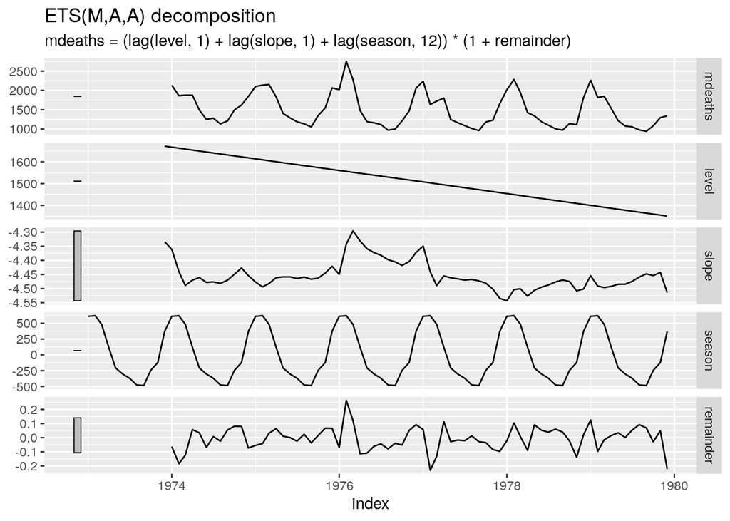

```r
uk_lung %>%
    model(ETS(mdeaths)) %>%
    components -> components_ts

components_ts %>% autoplot()
```

It may also be worth storing how these components can be used to produce the response, which can be used for decomposition modeling.